# Final Project

### 6.2.2 BIC/AIC values

An alternative method to evaluate and compare the suitability of various SIMRA models is by utilizing AIC (Akaike Information Criterion) and BIC (Bayesian Information Criterion) scores. In both instances, lower values of AIC and BIC indicate better-fitting models.

AIC and BIC evaluate models based on their goodness of fit and complexity. Both criteria consider the likelihood of the data fitting the model and penalize models for their complexity, effectively avoiding overfitting. By striking a balance between fit and complexity, AIC and BIC provide a comprehensive assessment of model quality.

```r
sc.AIC = AIC(m4_011_ML,base_111_ML,base_112_ML,base_211_ML,base_015_ML,base_012_ML,base_013_ML)

sc.BIC = BIC(m4_011_ML,base_111_ML,base_112_ML,base_211_ML,base_015_ML,base_012_ML ,base_013_ML)

# sc.BIC = AIC(m5_014.landing, m5_015.landing, m5_614.landing, m5_114.landing,
#              m5_115.landing, m5_1012.landing, m5_412.landing, m5_112.landing,
#              k = log(length(NMFS_Landings.ts)))

sort.score(sc.AIC, score = "aic")
```

```
##             df      AIC
## m4_011_ML    4 1483.568
## base_013_ML  6 1483.708
## base_211_ML  6 1484.183
## base_111_ML  5 1485.380
## base_012_ML  5 1485.475
## base_112_ML  6 1486.979
## base_015_ML  8 1487.630
```

```r
sort.score(sc.BIC, score = "bic")
```

```
##             df      BIC
## m4_011_ML    4 1491.669
## base_111_ML  5 1495.507
## base_012_ML  5 1495.602
## base_013_ML  6 1495.860
## base_211_ML  6 1496.335
## base_112_ML  6 1499.131
## base_015_ML  8 1503.833
```

### 6.2.3 Accuracy Scores

In addition to AIC and BIC, another approach to comparing the fit or accuracy of models is by utilizing various accuracy scores. These scores include metrics such as ME (Mean Error), RMSE (Root Mean Squared Error), MAE (Mean Absolute Error), MPE (Mean Percentage Error), MAPE (Mean Absolute Percentage Error), MASE (Mean Absolute Scaled Error), and ACF1 (Autocorrelation Function at lag 1).

Lower values for these accuracy metrics indicate a better fit in terms of the accuracy of the model. By assessing these metrics, one can gauge how well the model predicts or approximates the observed data. The selection of the model with the lowest values for these accuracy scores suggests its superior performance in accurately capturing the underlying patterns and trends in the data.

```r
Sm4_011_ML <- accuracy(m4_011_ML)[1:7]
Sbase_111_ML <- accuracy(base_111_ML)[1:7]
Sbase_112_ML <- accuracy(base_112_ML)[1:7]
Sbase_211_ML <- accuracy(base_211_ML)[1:7]
Sbase_015_ML <- accuracy(base_015_ML)[1:7]
Sbase_012_ML <- accuracy(base_012_ML)[1:7]
Sbase_013_ML <- accuracy(base_013_ML)[1:7]

df.Smodels <- data.frame(
  rbind(Sm4_011_ML, Sbase_111_ML, Sbase_112_ML, Sbase_211_ML,
        Sbase_015_ML, Sbase_012_ML, Sbase_013_ML)
)
colnames(df.Smodels) <- c("ME", "RMSE", "MAE", "MPE", "MAPE",
                          "MASE", "ACF1")
rownames(df.Smodels) <- c("SARIMA(0,1,1)x(2,1,0)_12","SARIMA(1,1,1)x(2,1,0)_12", "SARIMA(1,1,2)x(2,1,0)_12", "SARIMA(2,1,1)x(2,1,0)_12",
                          "SARIMA(0,1,5)x(2,1,0)_12", "SARIMA(0,1,2)x(2,1,0)_12", "SARIMA(0,1,3)x(2,1,0)_12")
round(df.Smodels,  digits = 3)
```

```
##                                 ME     RMSE      MAE    MPE  MAPE  MASE   ACF1
## SARIMA(0,1,1)x(2,1,0)_12 -1558.413 105731.8 72165.75 -0.129 2.019 0.614 -0.042
## SARIMA(1,1,1)x(2,1,0)_12 -2938.686 105795.6 72354.91 -0.166 2.020 0.616  0.001
## SARIMA(1,1,2)x(2,1,0)_12 -2804.154 105329.9 71654.10 -0.162 1.999 0.610  0.016
## SARIMA(2,1,1)x(2,1,0)_12  2249.273 100606.6 69026.11 -0.014 1.924 0.587 -0.021
## SARIMA(0,1,5)x(2,1,0)_12  3228.639 100428.4 68468.06  0.015 1.911 0.583 -0.016
## SARIMA(0,1,2)x(2,1,0)_12 -2543.015 105825.4 72425.96 -0.156 2.024 0.616 -0.020
## SARIMA(0,1,3)x(2,1,0)_12  3870.899 100153.2 67915.61  0.033 1.895 0.578 -0.009
```

In contrast, the SARIMA(0,1,1)x(2,1,0)_12 model did not achieve the best accuracy values and was ranked fourth or fifth in most categories.

## 6.3 Summary

After conducting parameter significance and residuals analysis, it was observed that the SARIMA(0,1,1)x(2,1,0)_12 model had the most significant parameters, indicating its suitability as an optimal fit. Additionally, the model achieved the lowest AIC and BIC scores, further supporting its strong performance.

Although the SARIMA(0,1,1)x(2,1,0)_12 model did not achieve the best accuracy scores, it is crucial to consider multiple model diagnostic tools for a comprehensive evaluation. By taking into account the consensus among these diagnostic tools, the SARIMA(0,1,1)x(2,1,0)_12 model emerges as the best choice for forecasting.

## 6.4 Model Diagnostics

To assess whether the SARIMA(0,1,1)x(2,1,0)_12 model is not underfit, we can employ model overfitting as an additional diagnostic tool. this approach involves increasing the values of both p (autoregressive order) and q (moving average order) in the SARIMA model. By doing so, we can examine if the number of significant parameters and the quality of fit improve, indicating potential underfitting in the initial SARIMA(0,1,1)x(2,1,0)_12 model.

```r
# Increasing the value of P
m4_111 <- Parameter.estimation(Data_ts_agg,c(1,1,1),c(2,1,0),method="ML",'43')
```

```
##
##  Shapiro-Wilk normality test
##
## data:  res.model
## W = 0.95747, p-value = 0.01942
```

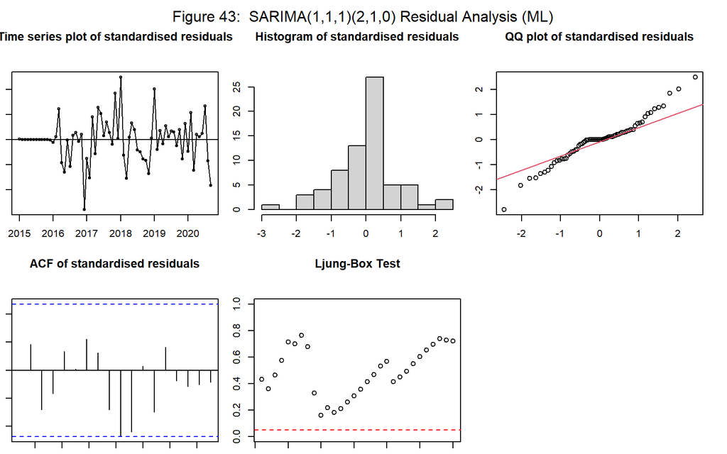

```
##
## z test of coefficients:
##
##      Estimate Std. Error z value  Pr(>|z|)
## ar1  -0.11184    0.30303 -0.3691   0.71209
## ma1  -0.72021    0.29987 -2.4017   0.01632 *
## sar1 -0.70556    0.17030 -4.1429 3.429e-05 ***
## sar2 -0.42200    0.15851 -2.6624   0.00776 **
## ---
## Signif. codes:  0 '***' 0.001 '**' 0.01 '*' 0.05 '.' 0.1 ' ' 1
```

By increasing the value of p the AR(1) is not significant , meaning no imporvement of fit has occured by overfitting the model in this direction.

```r
m4_012 <- Parameter.estimation(Data_ts_agg,c(0,1,2),c(2,1,0),method="ML",'44')
```

```
##
##  Shapiro-Wilk normality test
##
## data:  res.model
## W = 0.95775, p-value = 0.02012
```

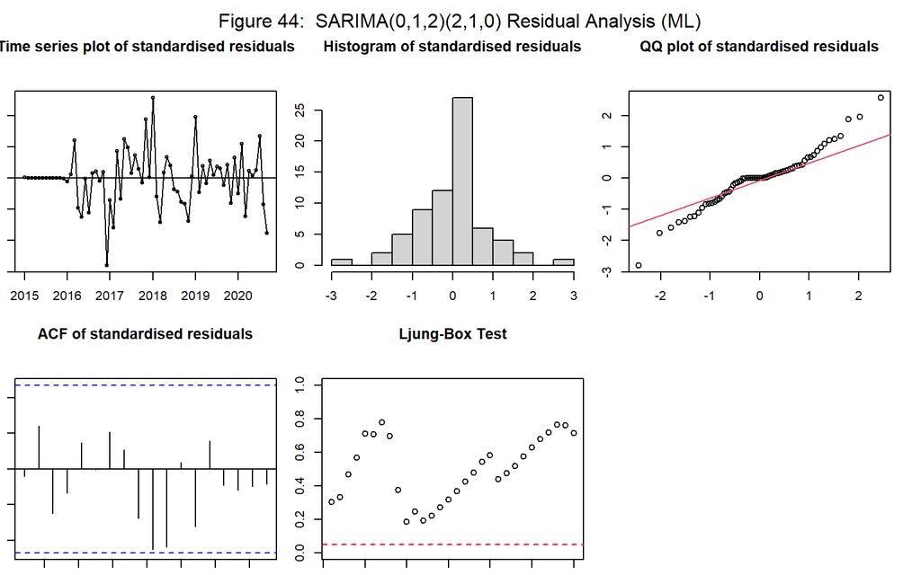

```
##
## z test of coefficients:
##
##       Estimate Std. Error z value  Pr(>|z|)
## ma1  -0.821572   0.149305 -5.5026 3.741e-08 ***
## ma2   0.048129   0.150831  0.3191  0.749658
## sar1 -0.712262   0.162707 -4.3776 1.200e-05 ***
## sar2 -0.416974   0.144295 -2.8897  0.003856 **
## ---
## Signif. codes:  0 '***' 0.001 '**' 0.01 '*' 0.05 '.' 0.1 ' ' 1
```

Upon increasing both the p and q values and evaluating the resulting models, no significant improvement was observed in the overall model fit. This suggests that the initial SARIMA(0,1,1)x(2,1,0)_12 model is not underfit. Consequently, there is no indication of an insufficient capturing of the underlying patterns and dynamics in the data.

Since increasing the p and q values did not lead to an improved fit, it can be concluded that the SARIMA(0,1,1)x(2,1,0)_12 model is already well-suited for the dataset at hand. This confirmation allows for greater confidence in proceeding with forecasting tasks using the established model.

## 6.5 Forecasting

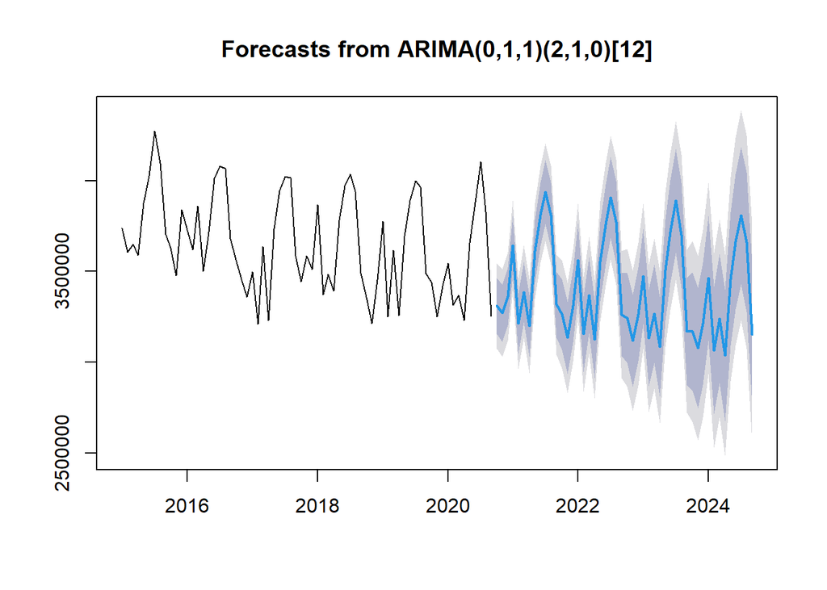

```r
m5_1012.landingA = Arima(Data_ts_agg,order=c(0,1,1),seasonal=list(order=c(2,1,0), period=12),
                          method = "ML")
# Notice that I use lambda = 0 and send NMFS_Landings.ts instead of log(NMFS_Landings.ts) to get Arima() function to do the transformation.
# This way, I will get the forecasts in the original scale.
preds1 = forecast(m5_1012.landingA,  h = 48)


plot(preds1)
```

From the forecast provided, it is evident that the SARIMA model SARIMA(0,1,1)x(2,1,0)_12 successfully captures the seasonal trends present in the data as well as the slowly decreasing trend. This indicates that the model is effectively accounting for the patterns and dynamics in the dataset.

However, it is important to note that as the forecasting horizon extends further into the future, the confidence interval for the predictions widens significantly. This widening of the confidence interval is expected, primarily due to insufficient data caused by data loss during monthly aggregation. With less historical data available for modeling and forecasting, there is increased uncertainty and variability in the predictions.

# 7. Conclusion

After conducting various model specification and parameter estimation techniques to analyze the Victoria energy demand time series, the SARIMA(0,1,1)x(2,1,0) model emerged as the most fitting model based on several supporting factors. The significance of its parameters and the favorable AIC/BIC scores obtained provide evidence for its goodness of fit.

On the other hand, a simpler deterministic model that combined linear and seasonal components also produced satisfactory forecasting results. However, this model may suffer from overfitting, as indicated by the large R-squared value recorded. Additionally, it lacks the capability to capture changing variances across different years. Consequently, the SARIMA model is slightly more preferable.

With the inclusion of more historical data, the SARIMA model can be utilized effectively in future renewable energy applications. It can accurately predict energy requirements on a monthly basis, enabling the estimation of necessary battery and grid capacities to support the transition towards renewables.

# 8. References